# Food Security Module, Ethiopia

Laura Hughes

July 6, 2015

## Basic characterization of Food Security Module

### Data

- LS/MS Baseline Household Surveys, 2011/2012 and 2013/2014
- Module 7 (Food security)

### General food security

#### Worries about food in the past week

In the past 7 days, did you worry your household would not have enough food?

| region | 2012 | 2014 |
| --- | --- | --- |
| SNNP | 27.2% | 21.2% |
| Oromia | 18.6% | 14.5% |
| other | 12.7% | 15% |
| Amhara | 10.6% | 13.5% |
| Tigray | 10% | 11.6% |
| Addis Ababa | NA | 15.8% |

#### Do worries correlate with self-reported changes in behaviour?

Comparing the self-reported worries about food security with self-reported changes to food consumption over the past week.

Changes to food consumption include:

- eating less desirable foods
- eating less diverse foods
- eating less food
- reducing the number of meals
- reducing adult consumption to provide more food for children
- borrowing food from family/friends
- not having any food supply
- fasting

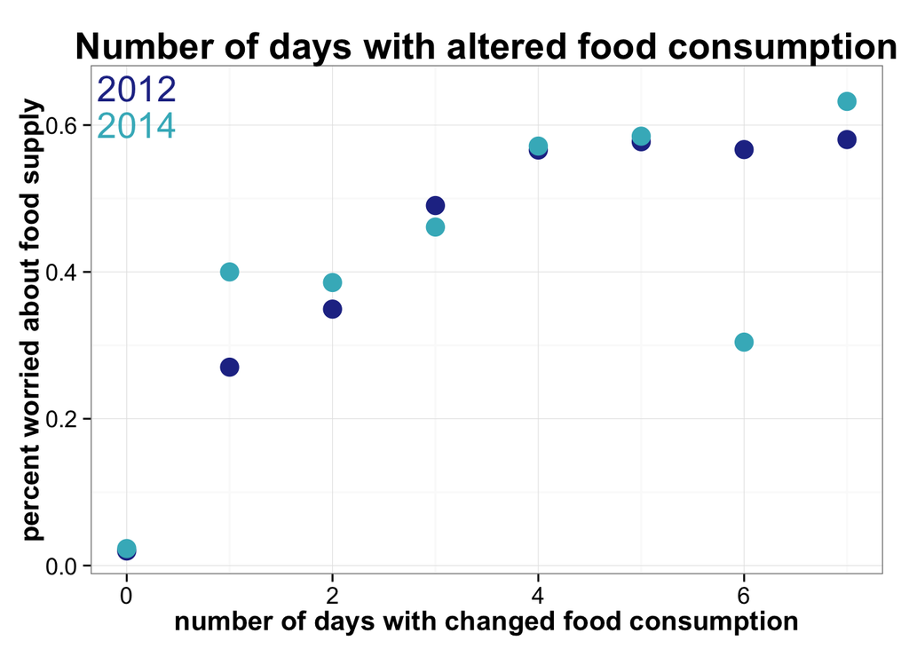

**Conclusion:** Asking people if they’re worried about their food supply is not necessarily indicative if they have changed their behavior.

#### If people do change their food consumption, how do they change it?

note: these percent of households do not take into account the number of days per week change occurred.

| change | 2012 | 2014 |
| --- | --- | --- |
| eat less preferred foods | 23.6% | 19.6% |
| limit food variety | 22.4% | 16.6% |
| reduce food intake | 19.9% | 13.2% |
| reduce number meals | 18.5% | 13% |
| reduce adult intake | 10.1% | 6.7% |
| borrow food | 7.1% | 4.5% |
| no food in household | 3.8% | 2.6% |
| fast | 2.9% | 1.2% |

### Household consumption characteristics

#### Meals per household

Most adults eat 3 or 2 meals per day, and there’s little regional variation. Children eat more meals – usually between 3 - 6 meals per day.

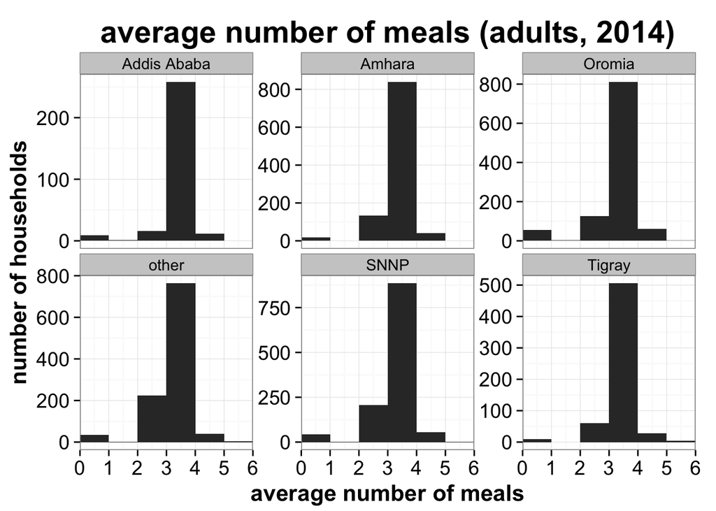

#### Diversity: men, women, kids: do they eat the same diet?

Not surprisingly, kids get more food at the expense of adults (though most people – > 90% – have the same diet across the household).

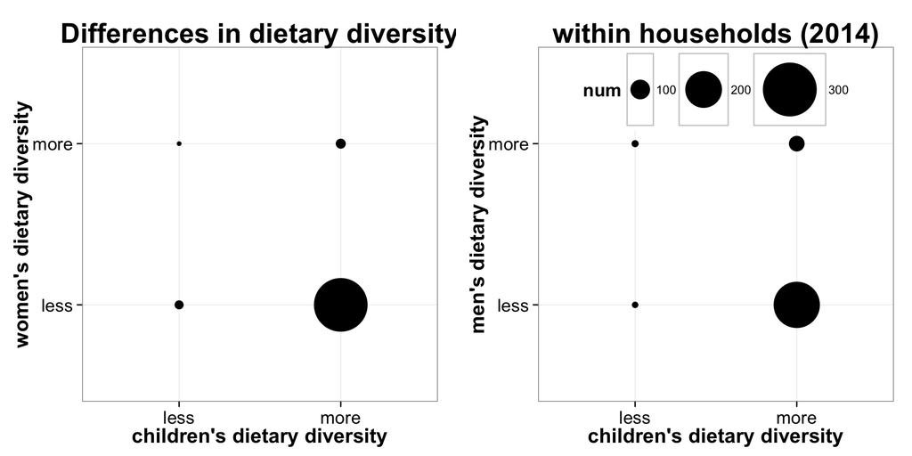

### Food security over time

- Food shortages are most prevalent in SNNP, and least prevalent in Addis Ababa.
- Food shortages peak in August at ~ 15% of all households.

In the last 12 months, have you been faced with a situation when you did not have enough food to feed the household?

| region | 2012 | 2014 |
| --- | --- | --- |
| SNNP | 38% | 35.1% |
| Oromia | 35.5% | 25.8% |
| Amhara | 23.6% | 29.3% |
| other | 20.4% | 27.6% |
| Tigray | 15.2% | 20.1% |
| Addis Ababa | NA | 7.4% |

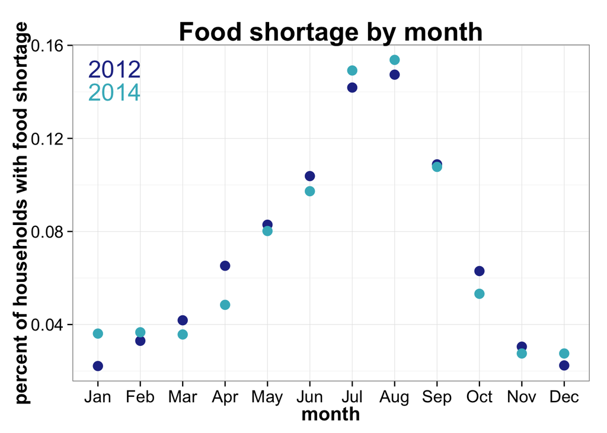

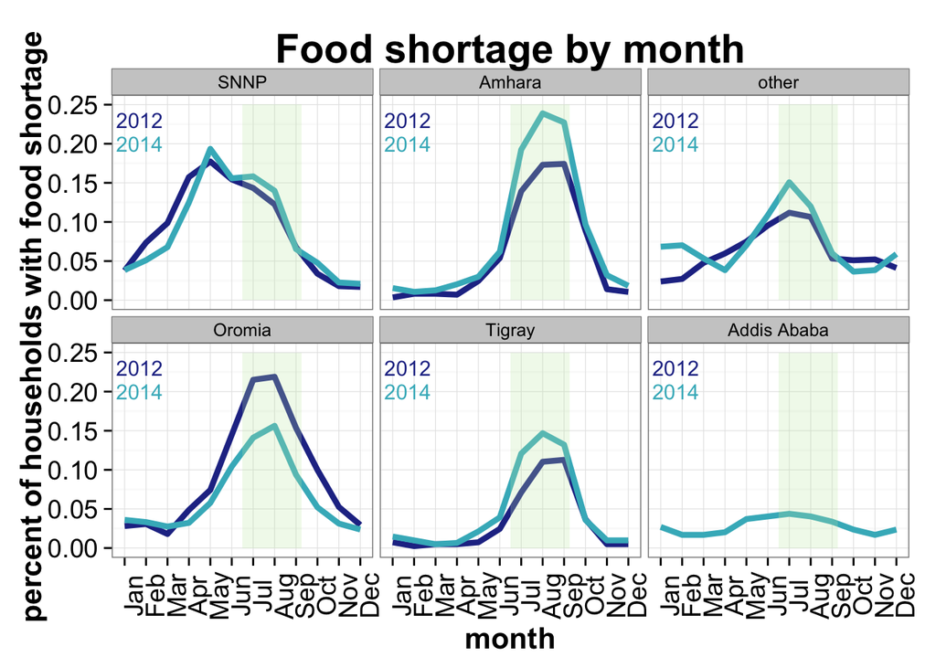

#### Why do people experience food shortages?

- Inadequate food supply due to small land size is the primary reason cited by households.
- When adding in all the reasons identified to contribute to food insecurity (first, second, and third most important factors), the primary factors were insufficient land area and increases in food prices within the markets.
- Drought was more of a problem in 2012, especially in SNNP and other regions.

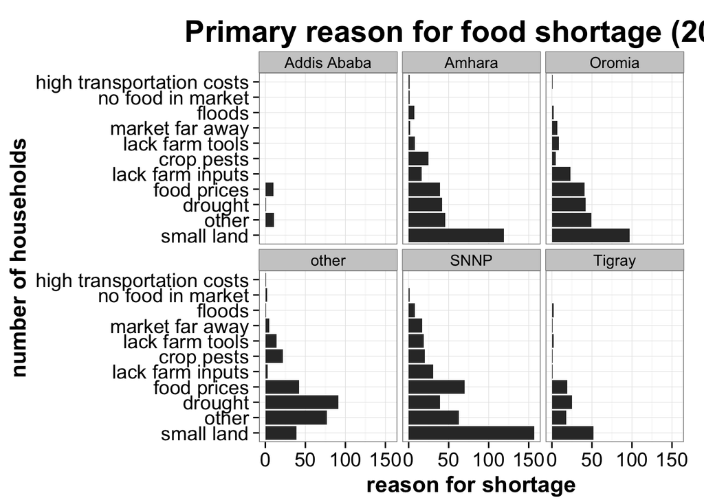

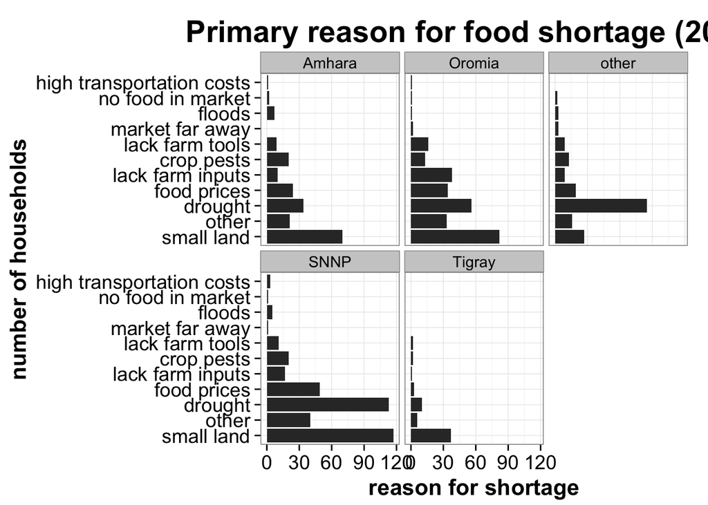

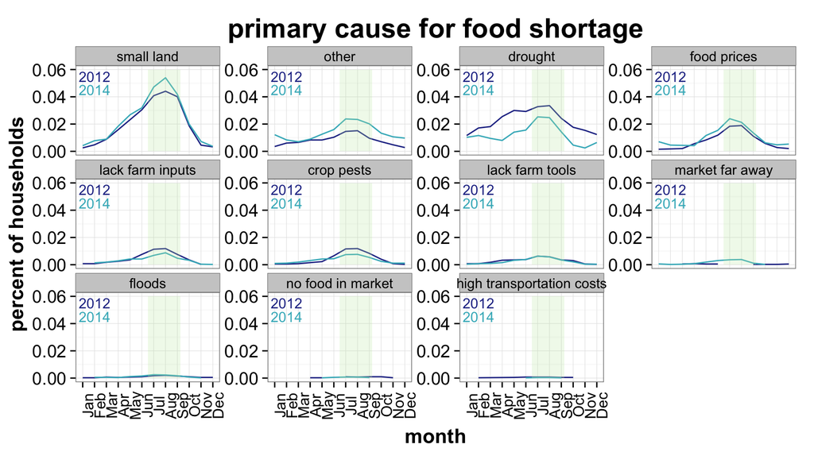

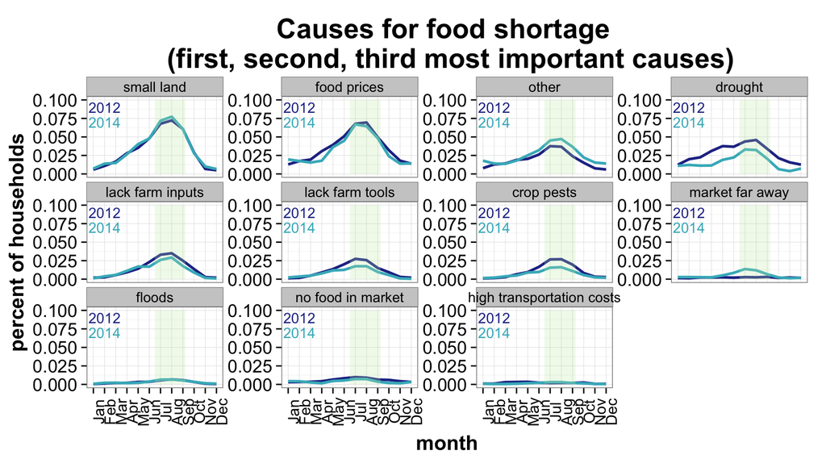

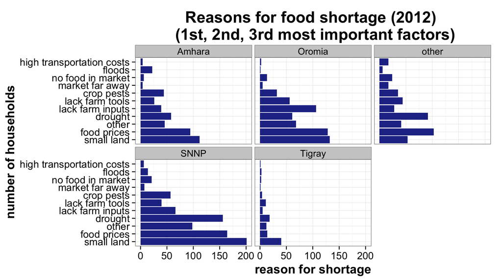

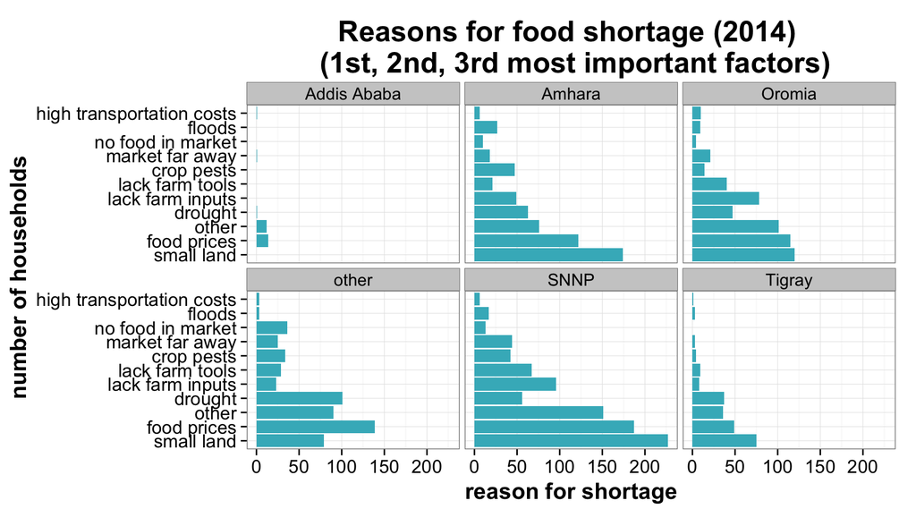